# Data Analysis Between Society and the Environment

## By: Ben Crawley, Cheng-Wei Lin, and Elizabeth Perkins

### CEB Visualization Team

```
## [1] "factor"
```

```
##    Min. 1st Qu.  Median    Mean 3rd Qu.    Max.
##  0.3766  0.5987  0.7290  0.7157  0.8286  0.9537
```

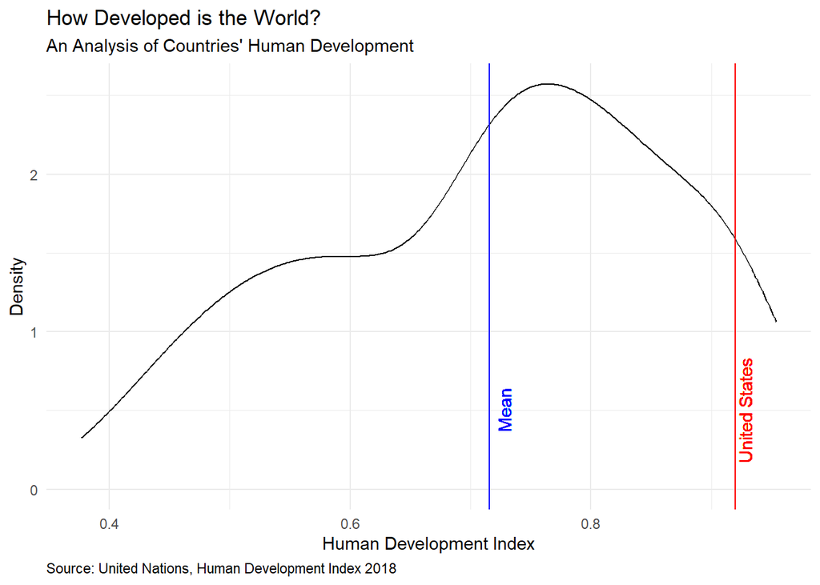

This plot analyzes the Human Development Index (HDI) to see how developed countries generally are. The index is on a scale from 0-1, where a higher score means the country is more developed. The mean development score for all countries is 0.72. As you can see on the plot, there is actually a large concentration of countries that are just above the mean with high development. The United States specifically is scored highly, at 0.92. The countries below the mean are more spread out with a larger variance of development.

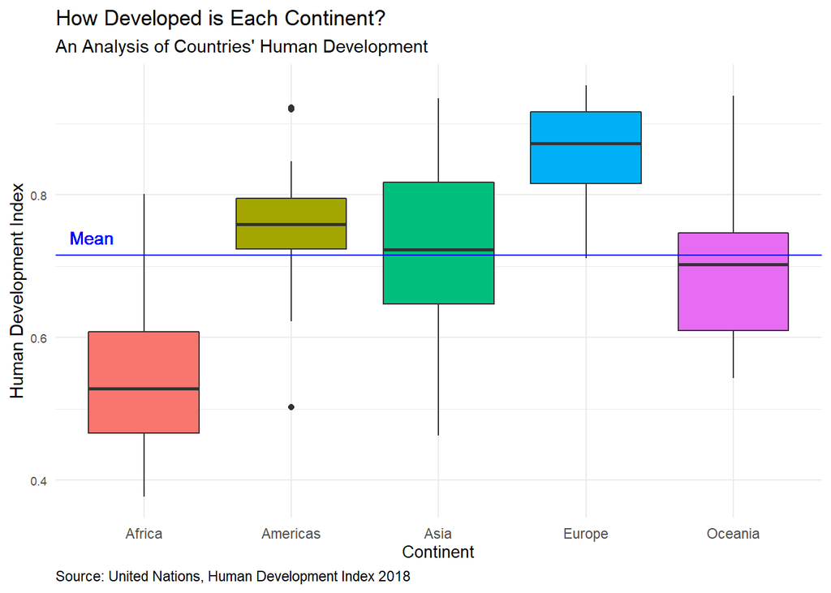

Here we can see the HDI broken out across each continent.This shows a few things about development across the world:

- The Americas and Europe are almost completely above the mean development score;
- Asia and Oceania are centered almost at the mean;
- Africa is solidly below the mean, which makes sense as there are many developing nations there.

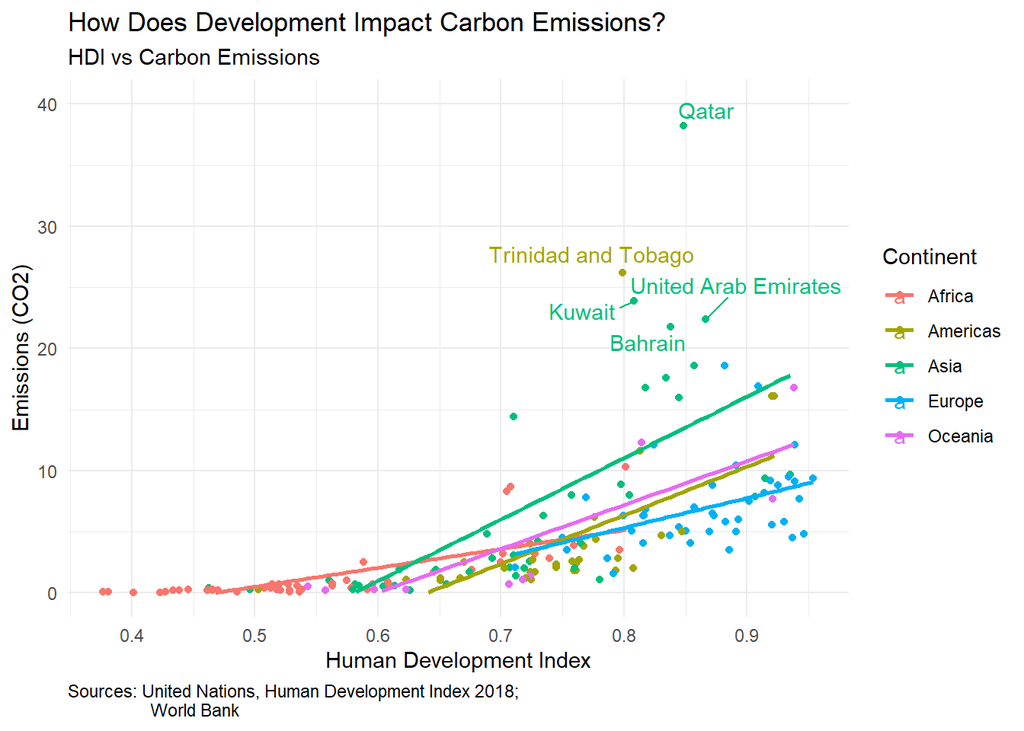

In this first bivariate analysis, it was important to see the relationship between development and carbon emissions. We speculated that more developed countries would produce higher emissions, as they drive more cars and have more industrial capacity. This scatterplot shows a clear trend that supports this. As the HDI score increases, carbon emissions also increases. The regression lines, broken out by continent, further shows this relationship.

There are several outliers (Qatar, UAE, Kuwait, Bahrain, Trinidad and Tobago) with emissions over 20 tons/capita. Almost all of these outliers belong ot the Middle East and are oil producing countries, so it is not surprising that their emissions are extremely high for their development.

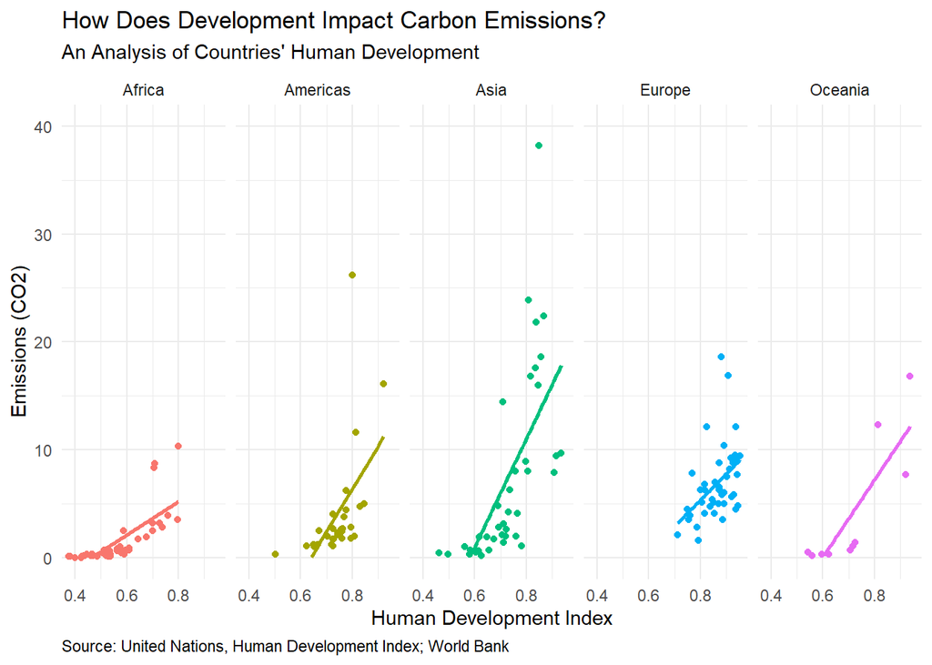

Here the previous scatterplot is further broken out by continent to see each continent’s trends. The relationship established previously holds true across each continent. However, the Asian continent (largely brought up by the Middle East) appears to produce a lot more emissions for higher development scores than other continents.